# Data Harmonization

Christian Pascual

# Purpose Of Notebook

Create a visualization that shows trends in age and race between two states, in face of different ways of collecting these data

```r
library(tidyverse)
library(pdftools)
library(rvest)
library(lubridate)
library(readxl)
```

# Helper Functions

```r
default_cols = c(
    "total",
    "age_0_19",
    "age_20_29",
    "age_30_39",
    "age_40_49",
    "age_50_59",
    "age_60_69",
    "age_70_79",
    "age_80+",
    "age_unk",
    "sex_male",
    "sex_female",
    "sex_unk",
    "ethnicity_hispanic",
    "ethnicity_non_hispanic",
    "ethnicity_unk",
    "race_white",
    "race_AfrA",
    "race_NatA",
    "race_asian",
    "race_other",
    "race_multi",
    "race_unk")

# Helper functions for data cleaning
skeleton_col = function(subdivs) {
  # Need to make a named vector to make it easier to insert data
  # in a cel-wise fashion

  # subdivs should contain all of the relevant information that
  # a state provides on their websitE

  skeleton = vector(mode = "list", length = length(subdivs))
  names(skeleton) = subdivs
  return(skeleton)
}
skeleton_table = function(subdivs) {
  # Create a table of blanks using named vectors
  # Easy insert of data
  skeleton = list(
    "data" = names(skeleton_col(subdivs)),
    "tested" = skeleton_col(subdivs),
    "cases" = skeleton_col(subdivs),
    "negatives" = skeleton_col(subdivs),
    "recovered" = skeleton_col(subdivs),
    "deaths" = skeleton_col(subdivs),
    "hospitalized" = skeleton_col(subdivs))
  return(skeleton)
}
```

# Bringing In Data

Using Florida and Tennessee as example states since I have the functions for those:

```r
florida = get_florida() %>%
  .$data %>% select(data, cases)
tennessee = get_tennessee("2020-05-09") %>%
  .$data %>% select(data, cases)
```

# Age Harmonization

Age is still numeric, so that will be the x-axis. To express the different bounds, we’ll show an age bound for each age and state. In order to plot it, we’ll just use the midpoint of this bound. Upper age brackets like 85+ limits will be shown at that point (85). Unknown age will be set to 100.

```r
fl_ages = florida %>%
  filter(
    data %in% c("age_0_4", "age_5_14", "age_15_24",
                "age_25_34", "age_35_44", "age_45_54",
                "age_55_64", "age_65_74", "age_75_84",
                "age_85+", "age_unk")) %>%
  mutate(
    bounds = map(data, function(s) {
      str_split(s, "_") %>% unlist %>% .[-1] %>% unlist
      }),
    left_bound = map_dbl(bounds, function(b) {
      if (length(b) == 2) {
        b[1] %>% as.numeric
      } else if (str_detect(b, "\\+")) {
        b %>% str_replace("\\+", "") %>% as.numeric
      } else {
        100 # default to 100 to show unknown on graph
      }
    }),
    right_bound = map_dbl(bounds, function(b) {
      if (length(b) == 2) {
        b[2] %>% as.numeric
      } else if (str_detect(b, "\\+")) {
        b %>% str_replace("\\+", "") %>% as.numeric
      } else {
        100 # default to 100 to show unknown on graph
      }
    }),
    mid = (left_bound + right_bound) / 2,
    state = "Florida"
  )

tn_ages = tennessee %>%
  filter(
    data %in% c("age_0_10", "age_11_20", "age_21_30",
                "age_31_40", "age_41_50", "age_51_60",
                "age_61_70", "age_71_80", "age_81+",
                "age_unk")) %>%
  mutate(
    bounds = map(data, function(s) {
      str_split(s, "_") %>% unlist %>% .[-1] %>% unlist
      }),
    left_bound = map_dbl(bounds, function(b) {
      if (length(b) == 2) {
        b[1] %>% as.numeric
      } else if (str_detect(b, "\\+")) {
        b %>% str_replace("\\+", "") %>% as.numeric
      } else {
        100 # default to 100 to show unknown on graph
      }
    }),
    right_bound = map_dbl(bounds, function(b) {
      if (length(b) == 2) {
        b[2] %>% as.numeric
      } else if (str_detect(b, "\\+")) {
        b %>% str_replace("\\+", "") %>% as.numeric
      } else {
        100 # default to 100 to show unknown on graph
      }
    }),
    mid = (left_bound + right_bound) / 2,
    state = "Tennessee"
  )

final_data = bind_rows(fl_ages, tn_ages) %>%
  mutate(
    cases = unlist(cases),
    state = factor(state),
    bracket_line = if_else(state == "Florida", -500, -1000)
    )
```

## Version 1

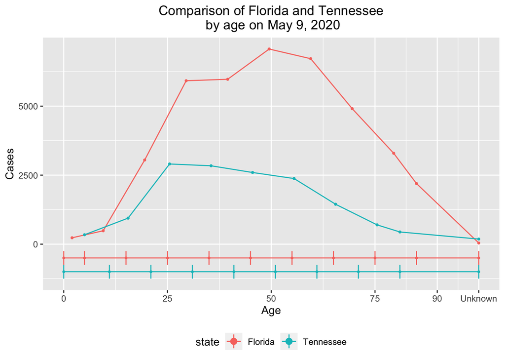

```r
final_data %>%
  ggplot(aes(color = state)) +
  geom_line(aes(x = mid, y = cases)) +
  geom_point(aes(x = mid, y = cases), size = 0.75) +
  geom_line(aes(x = left_bound, y = bracket_line)) +
  geom_pointrange(aes(x = left_bound,
                      y = bracket_line,
                      ymin = bracket_line - 250,
                      ymax = bracket_line + 250,
                      ), fatten = 0) +
  theme(legend.position = "bottom",
        plot.title = element_text(hjust = 0.5)) +
  scale_x_continuous(breaks = c(0, 25, 50, 75, 90, 100),
                     labels = c("0", "25", "50", "75", "90", "Unknown")) +
  labs(
    title = "Comparison of Florida and Tennessee\n by age on May 9, 2020",
    x = "Age",
    y = "Cases"
  )
```

## Version 2

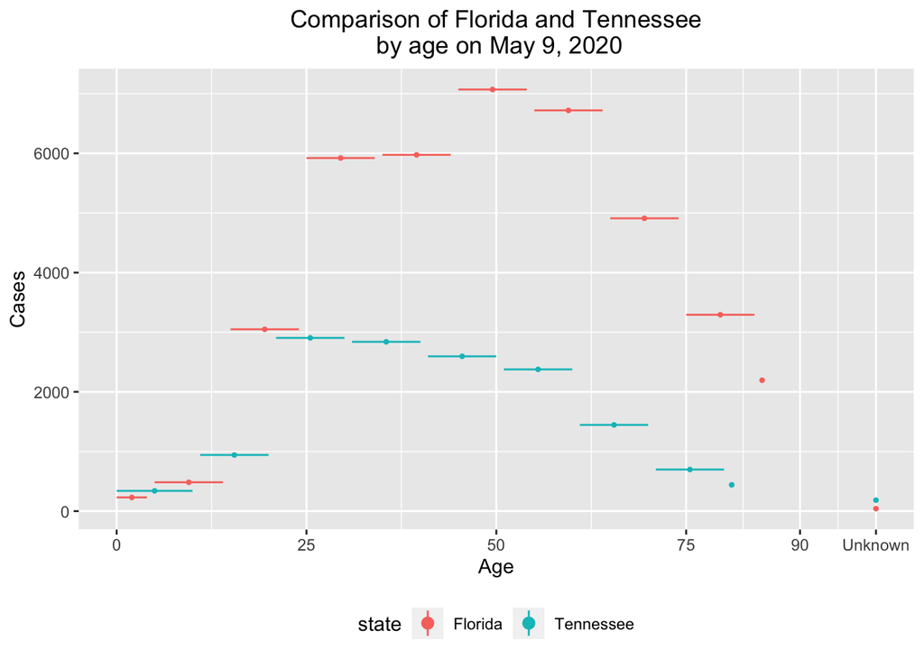

```r
final_data %>%
  ggplot(aes(color = state)) +
  geom_point(aes(x = mid, y = cases), size = 0.75) +
  geom_pointrange(aes(x = mid,
                      y = cases,
                      xmin = right_bound,
                      xmax = left_bound,
                      ), fatten = 0) +
  theme(legend.position = "bottom",
        plot.title = element_text(hjust = 0.5)) +
  scale_x_continuous(breaks = c(0, 25, 50, 75, 90, 100),
                     labels = c("0", "25", "50", "75", "90", "Unknown")) +
  labs(
    title = "Comparison of Florida and Tennessee\n by age on May 9, 2020",
    x = "Age",
    y = "Cases")
```

# Possible Improvements?

- Show each states age ranges as text on the chart? Might clutter the chart
- I feel like showing the midpoints captures this information well, but it might not do so well for states with very large age spans
- Maybe don’t show the unknowns since there’s so little of them?
- Try to use the Census data to standardize to X cases / 100,000 people? The differing age brackets will be a problem here.